# A systematic review of the efficacy of venlafaxine for the treatment of fibromyalgia - VanderWeide - 2015 - Journal of Clinical Pharmacy and Therapeutics - Wiley Online Library

[figure not shown]

# A systematic review of the efficacy of venlafaxine for the treatment of fibromyalgia

[L. A. VanderWeide PharmD](https://onlinelibrary.wiley.com/action/doSearch?ContribAuthorRaw=VanderWeide%2C+L+A),

[S. M. Smith PharmD MPH](https://onlinelibrary.wiley.com/action/doSearch?ContribAuthorRaw=Smith%2C+S+M),

[K. E. Trinkley PharmD](https://onlinelibrary.wiley.com/action/doSearch?ContribAuthorRaw=Trinkley%2C+K+E),

First published: 08 October 2014

https://doi.org/10.1111/jcpt.12216

Citations: 16

## Summary

### What is known and objective

Fibromyalgia is a painful disease affecting 1–2% of the United States population. Serotonin and norepinephrine reuptake inhibitors (SNRIs), such as duloxetine and milnacipran, are well studied and frequently used for treating this disorder. However, efficacy data are limited for the SNRI venlafaxine despite its use in nearly a quarter of patients with fibromyalgia. Accordingly, we systematically reviewed the efficacy of venlafaxine for treatment of fibromyalgia.

### Methods

PubMed, Web of Science and the Cochrane Database were searched using the terms ‘venlafaxine’ and ‘fibromyalgia’. Results were classified as primary studies or review articles based on abstract review. References of review articles were evaluated to ensure no primary studies evaluating venlafaxine were overlooked. All clinical studies that investigated venlafaxine for the treatment of fibromyalgia were included and graded on strength of evidence.

### Results and discussion

Five studies met the inclusion criteria, including 4 open-label cohort studies and 1 randomized, controlled trial. Study durations ranged from 6 weeks to 6 months, and study sizes ranged from 11 to 102 participants. Four of the five published studies reported improvement in at least one outcome. Generally consistent improvements were observed in pain-related outcome measures, including the Fibromyalgia Impact Questionnaire (range, 26–29% reduction; *n* = 2 studies), Visual Analog Scale (range, 36–45% reduction; *n* = 2 studies), McGill Pain Questionnaire (48% reduction; *n* = 1 study) and Clinical Global Impression scale (51% had significant score change; *n* = 1 study). However, the few studies identified were limited by small sample size, inconsistent use of outcomes and methodological concerns.

### What is new and conclusion

Studies assessing the efficacy of venlafaxine in the treatment of fibromyalgia to date have been limited by small sample size, inconsistent venlafaxine dosing, lack of placebo control and lack of blinding. In the context of these limitations, venlafaxine appears to be at least modestly effective in treating fibromyalgia. Larger randomized controlled trials are needed to further elucidate the full benefit of venlafaxine.

## What is known and Objective

Fibromyalgia is generally characterized by chronic musculoskeletal pain and some degree of cognitive dysfunction. Prior to recent clarification from the American College of Rheumatology (ACR),1-5 the diagnosis of fibromyalgia had been challenging, leading to difficulties in characterizing the epidemiology of the disease. The prevalence of fibromyalgia in the United States has been estimated between 1% and 2% of the population, or approximately 5 million Americans; the prevalence is 64% greater in women compared to men.6-8 The economic burden of the illness in the United States has been estimated to be nearly $8000 per person annually in direct costs, with individual out of pocket costs of nearly $1800. Indirect costs (e.g. absenteeism, loss of productivity) were estimated to be nearly $11 000 annually.9

Given the burden of fibromyalgia on the patient and society, effective treatment is necessary and is primarily symptom based, involving both pharmacologic and non-pharmacologic approaches. The recommended non-pharmacologic treatment for appropriate patients with fibromyalgia includes cognitive therapy, exercise and other multidisciplinary approaches (e.g. biofeedback, acupuncture and chiropractic manipulation) in addition to patient education.10, 11

Although the efficacy of non-pharmacologic therapy has been established, for most patients, the choice of pharmacologic therapy is less clear. Pharmacologic treatment for fibromyalgia spans a wide range of medications with a variety of different mechanisms. Historically, the commonly recommended pharmacologic treatments for fibromyalgia include tricyclic antidepressants (TCAs), selective serotonin reuptake inhibitors (SSRIs), non-steroidal anti-inflammatory drugs (NSAIDs), opioid analgesics and acetaminophen (APAP).10, 11 More recently, the use of serotonin and norepinephrine reuptake inhibitors (SNRIs) has gained increased acceptance as viable treatment options for fibromyalgia.

The use of SNRIs is based on the observation that low levels of norepinephrine and serotonin may be present in patients with fibromyalgia.12 As these neurotransmitters are crucial in pain modulation, medications increasing them may result in symptom improvement. Most of the evidence supporting SNRI use in fibromyalgia stems from studies demonstrating efficacy with duloxetine and milnacipran.13-16 However, in clinical practice, venlafaxine, which is available generically, may be an attractive option due to lower costs and the availability of short-acting and long-acting formulations. Unfortunately, data on the use of venlafaxine to treat fibromyalgia are limited, and to date, there are no published reviews on this topic. Despite the limited data, venlafaxine is used in nearly a quarter of patients being treated for fibromyalgia.17 Accordingly, we reviewed and report herein the evidence evaluating the use of venlafaxine for the treatment of fibromyalgia.

## Methods

Table 1. Evidence grading criteria used for evaluating the quality of studies of venlafaxine use in fibromyalgia

| Level of evidence | Quality of evidence |
| --- | --- |
| 1A: High quality | Randomized controlled trial (RCT) with no limitations |
| 1B: Moderate quality | RCT with significant limitations (lack of placebo control, not well reported findings, small sample size) |
| 2A: Low quality | Open-label trial with few limitations |
| 2B: Very low quality | Open-label trial with significant limitations (presented only as an abstract, very small sample size) |

## Results and Discussion

The literature search identified one randomized, placebo-controlled trial and 4 open-label trials that are summarized in Table 2. Figure 1 displays the exclusion process for the selected studies. Analysis of the review article references did not identify any further studies that were missed in the database search results.

Table 2. Study design, intervention type and level of evidence of studies assessing efficacy of venlafaxine for fibromyalgia published prior to August 2014

| Study | Design | Intervention | *N* | Duration | Level of evidence |
| --- | --- | --- | --- | --- | --- |
| Dwight *et al*.19 | OL | Variable doses of venlafaxine. Mean final dose of 167 mg | 11 | 8 weeks | 2A |
| Sayar *et al*.20 | OL | Fixed dose of 75 mg of venlafaxine | 15 | 12 weeks | 2A |
| Evren *et al*.21 | OL | Fixed dose of 75 mg of venlafaxine | 20 | 10 weeks | 2B |
| Diaz-Marsa *et al*.22 | OL | Flexible dose venlafaxine (150–300 mg). Mean final dose of 156 mg | 102 | 6 months | 2A |
| Zijlstra23 | R, PC | Fixed dose of 75 mg of venlafaxine or placebo | 90 | 6 weeks | 1B |

- *N*, number of subjects; OL, open label; R, randomized; PC, placebo controlled.

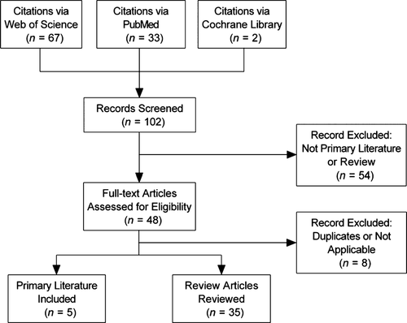

**Figure 1**

Screening flow diagram outlining the literature search process.

The first study identified was an open-label trial of 11 patients with fibromyalgia who were given varying doses of venlafaxine, titrated up to 375 mg per day (or the maximum tolerated dose below that) for 8 weeks.19 The coprimary outcomes were the difference from baseline to study end for each of the Hamilton Depression (HAM-D) scale, Hamilton Anxiety (HAM-A), the McGill Pain Questionnaire (MPQ), the Visual Analog Scale (VAS) and the Psychosocial Adjustment to Illness Scale-Self Report (PAIS-SR). An improvement of at least 50% on the McGill Pain Questionnaire and VAS summary score was considered to be a positive response. At 8 weeks, the mean daily dose of venlafaxine was 167 mg and 55% of the patients had a positive response to treatment. Each of the outcome measures had an improvement from baseline to 8 weeks. Specifically, MPQ score decreased by 11·1 (*P* < 0·01), VAS score decreased by 18·7 (*P* < 0·01), HAM-D score decreased by 4·65 (*P* < 0·02), HAM-A score decreased by 7·14 (*P* < 0·02), and PAIS-SR score decreased by 10·0 (*P* < 0·05) (Table 3).

Table 3. Summary of trials evaluating venlafaxine use in fibromyalgia

| Clinical Measure | Generally Accepted Minimum for Improvement | Study Dwight *et al*. Absolute change | Study Dwight *et al*. Percentage Change | Study Sayar *et al*. Absolute Change | Study Sayar *et al*. Percentage Change | Study Evren *et al*. Absolute Change | Study Diaz-Marsa *et al*. Absolute Change | Study Diaz-Marsa *et al*. Percentage Change | Study Zijlstra *et al*. Absolute Change | Study Zijlstra *et al*. Percentage Change |
| --- | --- | --- | --- | --- | --- | --- | --- | --- | --- | --- |
| FIQ | 13–14% score change considered clinically important differences30 | n/a | n/a | −15·8 (<0·001) | −29% | n/a | −19·9 (*P* < 0·001) | −26% | −9·0 (*P* = 0·032) | n/a |
| MPQ | Defined as 50% reduction in Dwight et al19 | −11·1 (*P* < 0·01); 55% had >50% reduction | −48% | n/a | n/a | n/a | n/a | n/a | n/a | −10% (NS) |
| VAS | Defined as 50% reduction in Dwight et al19 | −18·7 (*P* < 0·01); 55% had >50% reduction | −45% | −21·4 (*P* < 0·001) | −36% | NRa | n/a | n/a | n/a | n/a |
| VAS Pain | Varies based on baseline score: Range 7–3731 | n/a | n/a | n/a | n/a | n/a | −13·4 (*P* < 0·001) | −19% | n/a | −10% (NS) |
| VAS-Fatigue | Not established | n/a | n/a | n/a | n/a | n/a | −26·2 (*P* < 0·001) | −35% | n/a | n/a |
| CGI | Change score of 1 or 2 (much or very much improved)22 | n/a | n/a | n/a | n/a | n/a | n/a | 51% experienced significant score change | n/a | n/a |
| GAF | Not established | n/a | n/a | n/a | n/a | n/a | +18·3 (*P* < 0·001) | +34% | n/a | n/a |
| PAIS-SR | Not established | −10·0 (*P* < 0·05) | −29% | n/a | n/a | n/a | n/a | n/a | n/a | n/a |
| HAM-D | Response is ≥50% reduction from baseline; remission is score ≤732 | −4·65 (*P* = 0·02) | −46% | −4·5 (*P* = 0·001) | −40% | NRa | −3·6 (*P* < 0·001) | −27% | n/a | n/a |
| HAM-A | Response is ≥50% reduction from baseline; remission is score ≤733 | −7·14 (*P* = 0·02) | −53% | −13·5 (*P* < 0·001) | −63% | NRa | n/a | n/a | n/a | n/a |
| BDI | Response is ≥50% reduction from baseline; remission is score ≤934 | n/a | n/a | −7·9 (*P* = 0·023) | −38% | NRa | n/a | n/a | NS | n/a |
| BAI | Not established | n/a | n/a | −8·5 (*P* = 0·002) | −31% | NRa | n/a | n/a | n/a | n/a |
| Comments |  |  |  |  |  | Presented in abstract form only. | Better response noted with major depression |  | Negative results, but low dose of venlafaxine; presented in abstract form only. |  |

- Data presented as reported absolute change (*P*-value) from baseline to study end and as a percentage change from baseline to study end. A ‘+’ indicates an increase in the value from baseline; a ‘−’ indicates a decrease in the value from baseline.
- <sup>*a*</sup> Significant improvement reported, but point estimates and *P*-values were not reported.
- FIQ, Fibromyalgia Impact Questionnaire; n/a, not assessed; MPQ, McGill Pain Questionnaire; NS, not significant; VAS, Visual Analog Scale; CGI, Clinical Global Impression; GAF, Global Assessment of Function; PAIS-SR, Psychosocial Adjustment to Illness Scale-Self Report; HAM-D, Hamilton Depression scale; HAM-A, Hamilton Anxiety scale; BDI, Beck Depression Inventory; BAI, Beck Anxiety Inventory.

The second open-label trial evaluated the efficacy of venlafaxine 75 mg daily in 15 patients for 6 and 12 weeks on the primary outcomes of the change in score from baseline to 12 weeks of the Fibromyalgia Impact Questionnaire (FIQ) and the VAS.20 Secondary outcomes were the change in score from baseline of the Beck Depression Inventory (BDI), the Beck Anxiety Inventory (BAI), HAM-D score and HAM-A score. From baseline to week 12, an improvement was observed in the VAS (decrease of 21·4; *P* = 0·0001) and FIQ (decrease of 15·8; *P* = 0·0001); the improvement in VAS was observed only from week 6 to week 12. The BDI did not improve from baseline to week 6, but decreased by 7·9 from week 6 to week 12 (*P* = 0·023). The BAI decreased 8·5 by week 6 (*P* = 0·002), but did not significantly drop from week 6 to week 12. The HAM-A decreased by 13·5 by week 12 (*P* = 0·0001). The HAM-D score decreased by 4·5 by week 6 (*P* = 0·001), but did not significantly decrease from week 6 to week 12 (Table 3).

The third open-label trial evaluated the efficacy of 75 mg of venlafaxine in 20 patients for 5 and 10 weeks with outcomes of change in score from baseline of the VAS, BDI, BAI, HAM-A and HAM-D scores.21 The study was only presented in abstract form and reported a significant improvement in all outcome measures, but did not report measures of significance (Table 3).

The studies identified in this review provide a helpful perspective on the role of venlafaxine for the treatment of fibromyalgia. Of the 5 studies identified, 4 were open-label studies. All of these open-label studies found an improvement in fibromyalgia symptoms or global function following treatment with venlafaxine, but do not account for the placebo effect. The one randomized, placebo-controlled trial evaluating venlafaxine failed to find an improvement in fibromyalgia symptoms in the intention-to-treat analysis, but when analysed per protocol, an improvement was seen in the FIQ scale. The FIQ scale has been used since 1991 to measure the effects of fibromyalgia on patient's daily lives. This tool measures three major components including function, overall impact and symptoms. Improvement in the FIQ scale indicates that patients with fibromyalgia perceive improvement in their symptoms, which is a clinically meaningful outcome.24 However, the findings of this placebo-controlled study should be interpreted with some caution as to their applicability to real-world use of venlafaxine in this population.25 In particular, lack of a complete publication with adequate peer review makes it challenging to assess reasons (e.g. medication non-adherence, lack of hi-fidelity conformity to the protocol) for the discrepancy between analysis methodologies.

These studies all have significant limitations as seen in the grading of the evidence, which make translating findings into clinical practice difficult. Only 2 of the studies had a sample size of greater than 20 patients,22, 23 and the 4 studies without placebo control make them very susceptible to the placebo effect,19-22 further limiting their usefulness. Further, the trial that did use a placebo control used a comparatively low dose of venlafaxine, which may have contributed to the insignificant differences in the primary outcome in the intention-to-treat analysis.23 Two of the studies were only available in abstract form, limiting the ability to thoroughly assess the rigour of the research methods and results.21, 23

Despite all of these limitations, these studies, in aggregate and combined with more rigorous evidence supporting the use of other SNRIs,13-16 suggest there may be a benefit to using venlafaxine in fibromyalgia. Furthermore, from a pharmacologic perspective, there are no obvious reasons to believe that venlafaxine would be less effective than milnacipran or duloxetine. Although robust evidence supporting the use of venlafaxine for fibromyalgia is lacking, it is also important to consider the risks associated with venlafaxine. Although safety was not a primary objective of the studies presented here, the safety profile of venlafaxine has been established in other robust studies assessing its use in depression.26-28 In these studies, common side effects were nausea, insomnia, dizziness, somnolence, constipation and sweating. Some mild increases in blood pressure have been observed with the use of venlafaxine, but the significance of this finding is thought to be minimal,29 as is the severity of venlafaxine's general adverse effect profile.

One final noteworthy point is that the time frame over which venlafaxine may exert its effect in patients with fibromyalgia has not been well described to date. For example, it is commonly known that SNRIs and other serotonergic medications take several weeks to exert their full beneficial effect in the treatment of depression, although the precise mechanism remains under debate. Whether a similar time frame is optimal for assessing treatment failure in patients with fibromyalgia is unknown. To date, trials of venlafaxine's use in fibromyalgia have ranged from 6 weeks to 6 months in duration. Although some studies showed an improvement in outcomes at 6 weeks, one of the open-label trials found that it took up to 12 weeks to find significant improvement in several outcomes like the VAS and HAM-A, whereas other factors were already improved at 6 weeks (BAI and HAM-D).20 Additional research is needed to clarify optimal trial duration for these agents; however, until further data are available, 12-week treatment trials may be sufficient to determine treatment success or failure.

Although SNRIs as a class appear to be potentially efficacious for use in fibromyalgia, there are several factors that may make venlafaxine a preferred option compared to the other SNRIs. Although a full cost analysis is beyond the scope of this review, for many providers and patients, a primary driver for choosing venlafaxine may be cost. Currently, several other SNRIs, milnacipran and desvenlafaxine, are only available in the United States in a brand name formulation, whereas venlafaxine is available generically. Despite duloxetine recently becoming available as a generic product, costs should not be expected to fall significantly for some time. Another consideration is the incident use of venlafaxine for fibromyalgia. Although aggregate usage rates may be affected by region, facility or provider, one study using the Human Capital Management Services Research Reference Database estimated that venlafaxine comprised nearly a quarter of all medications prescribed for fibromyalgia.17 This observation may indicate that despite the limited evidence for venlafaxine, many patients – and by extension, providers – have had positive clinical experiences with using venlafaxine for fibromyalgia.

## What is new and Conclusion

Despite the lack of robust evidence supporting its use, venlafaxine may be effective for the treatment of fibromyalgia. Most trials of venlafaxine demonstrate positive or neutral benefits for fibromyalgia. Venlafaxine is generally well tolerated, and given its lower cost, venlafaxine may be a more affordable option compared to the other, more expensive SNRIs. Additional randomized, controlled, double-blind, parallel design studies that are well powered are needed to better understand the role of venlafaxine in the treatment of fibromyalgia. Until additional studies are available, the evidence suggests venlafaxine may be reasonable to consider for the treatment of fibromyalgia, especially when cost is a factor in the clinical decision making.

## Conflicts of Interest and Funding Disclosure

The authors report no conflict of interest or external funding related to this work.

[figure not shown]

[figure not shown]